# Исследование: Прогноз активности покупателей интернет-магазина

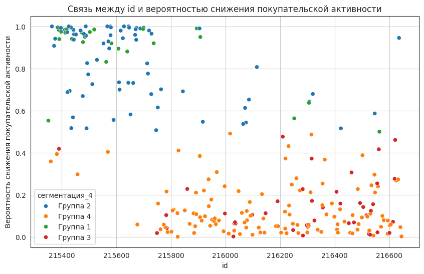

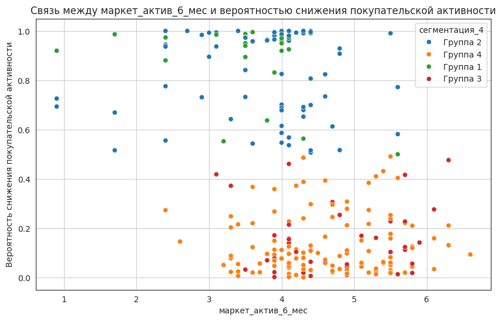

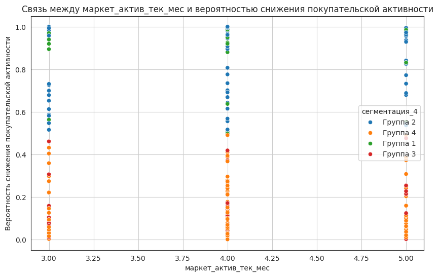

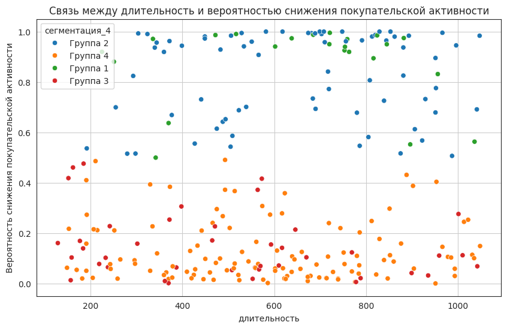

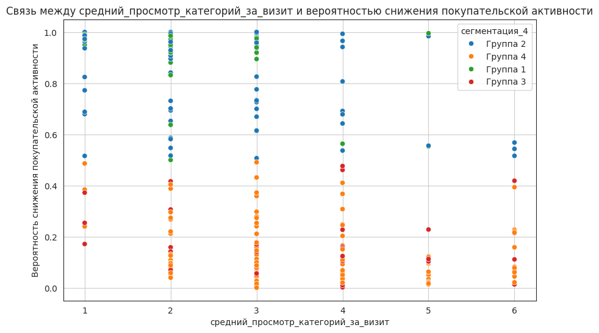

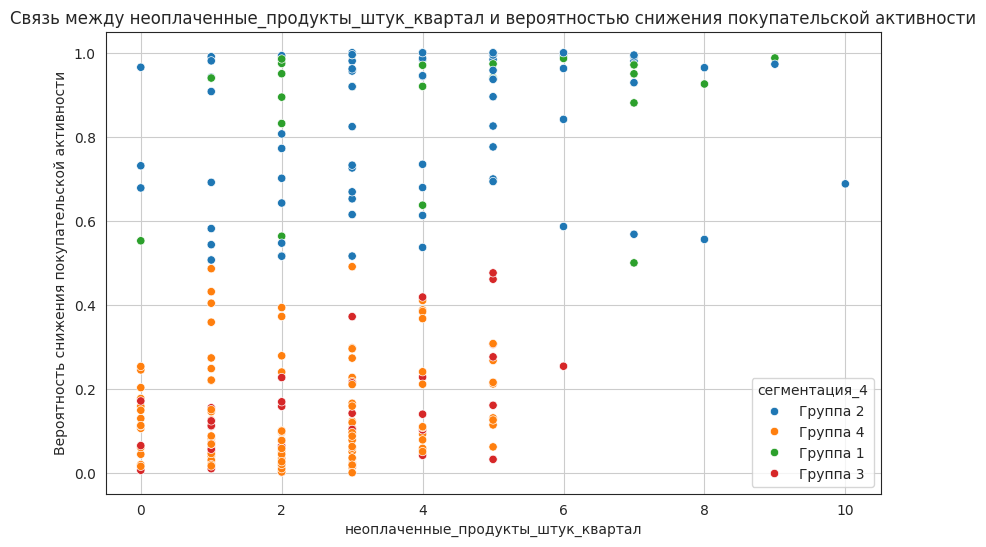

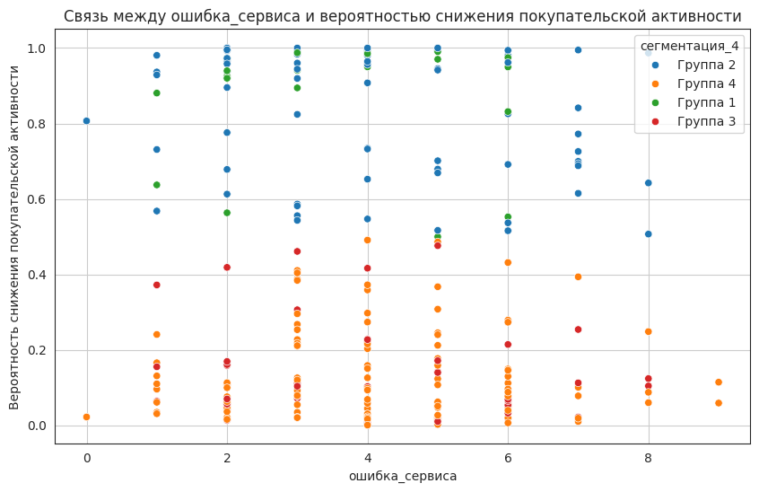

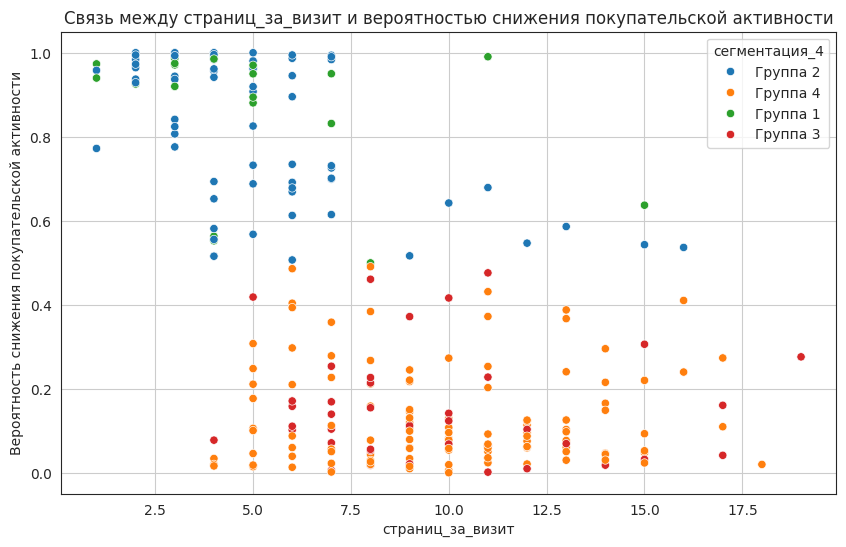

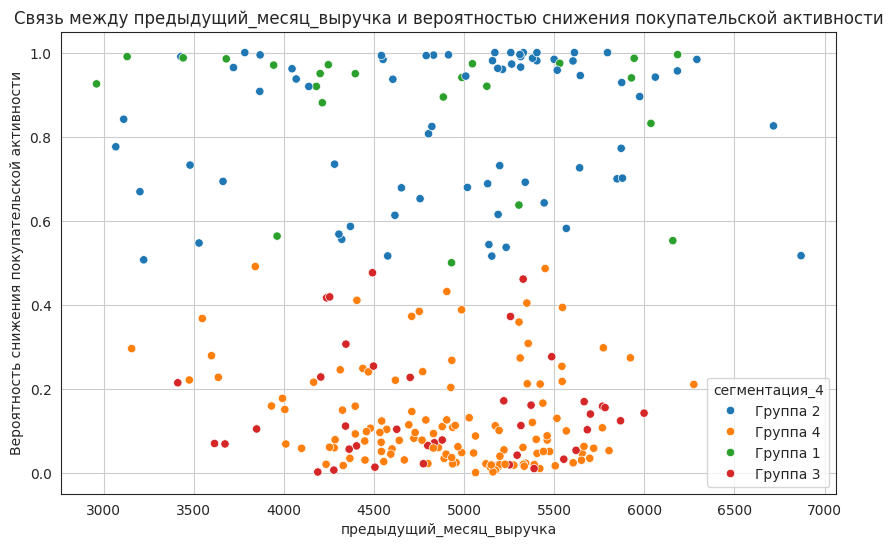

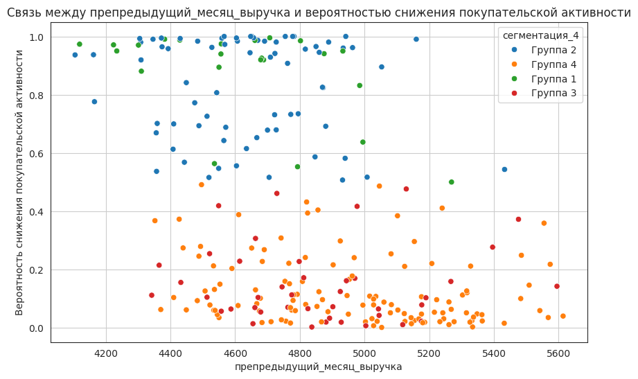

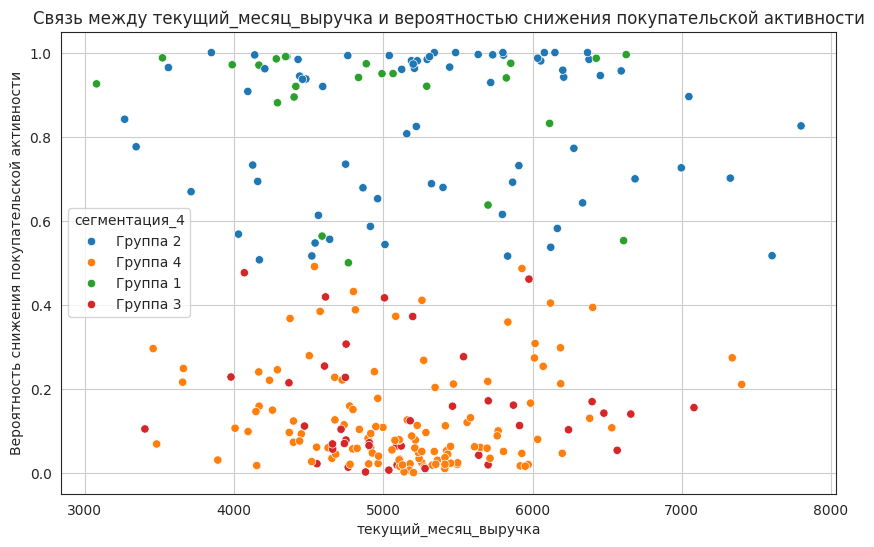

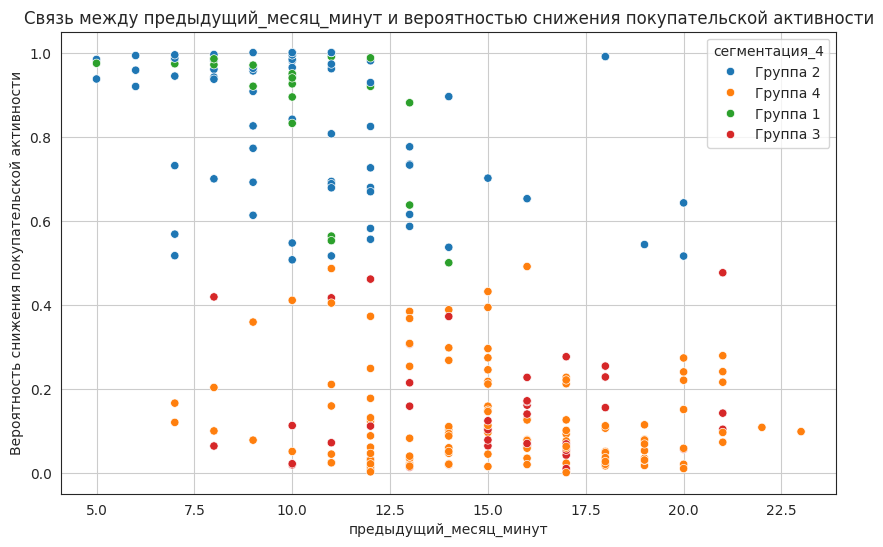

[5 more figures not shown]

```python
for column in X_test_full.select_dtypes(include=['number']).columns:
    plt.figure(figsize=(10, 6))
    sns.scatterplot(data=X_test_full, x=column, y='вероятность_снижения_покупательской_активности', hue='сегментация_4')
    plt.title(f'Связь между {column} и вероятностью снижения покупательской активности')
    plt.xlabel(column)
    plt.ylabel('Вероятность снижения покупательской активности')
    plt.grid(True)
    plt.show()
```

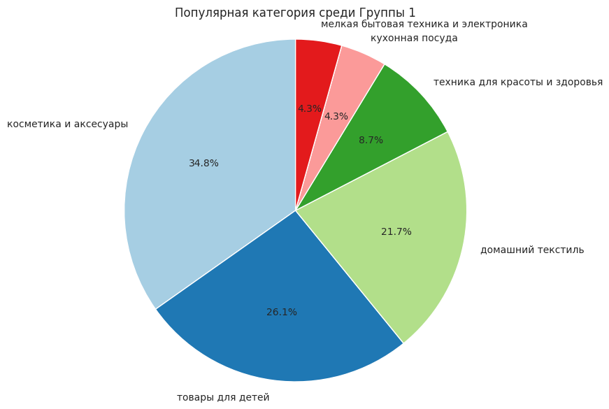

```python
plot_pie_chart(
    X_test_full.query('сегментация_4 == "Группа 1"'),
    'популярная_категория',
    'Популярная категория среди Группы 1')
```

Имеет смысл сосредоточиться на клиентах с высокой прибыльностью и высокой вероятностью снижения активности, т.к. эти клиенты приносят много прибыли и составляют около 10% от общего количества покупателей. Самый популярная категория "Косметика и аксесуары" и "Товары для детей".

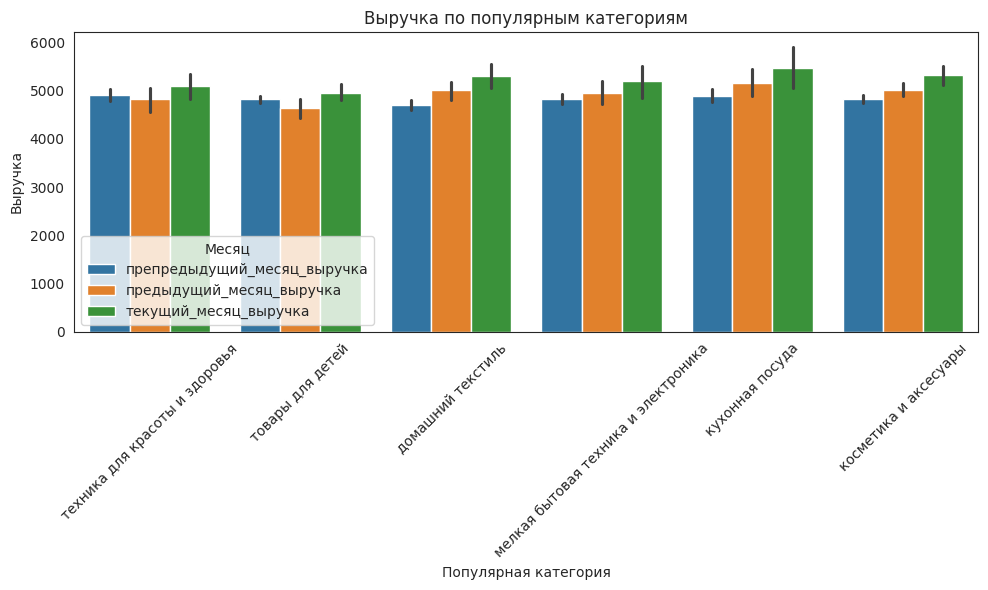

```python
# Преобразование данных для построения графика
X_test_melted = X_test_full.melt(id_vars='популярная_категория',
                                   value_vars=['препредыдущий_месяц_выручка', 'предыдущий_месяц_выручка', 'текущий_месяц_выручка'],
                                   var_name='месяц', value_name='выручка')

# Построение графика
plt.figure(figsize=(10, 6))
sns.barplot(data=X_test_melted, x='популярная_категория', y='выручка', hue='месяц')

plt.title('Выручка по популярным категориям')
plt.xlabel('Популярная категория')
plt.ylabel('Выручка')
plt.legend(title='Месяц')
plt.xticks(rotation=45)
plt.tight_layout()
plt.show()
```

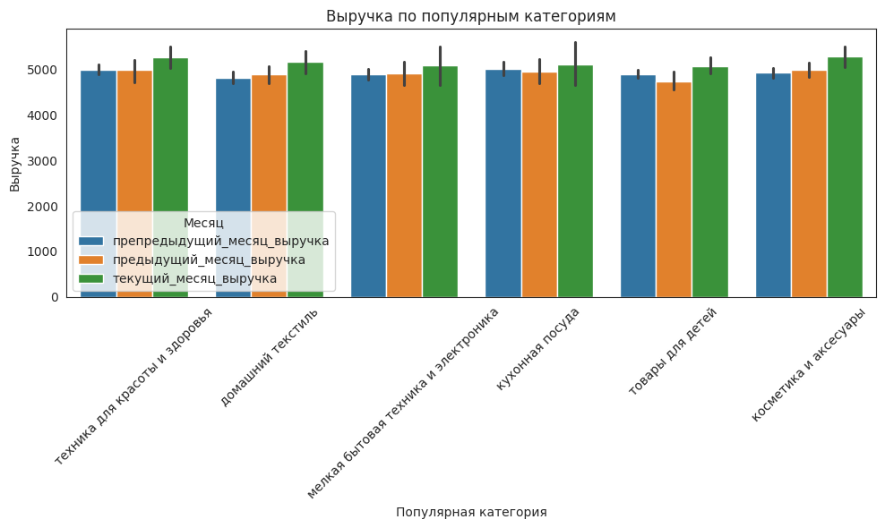

```python
# Преобразование данных для построения графика
X_test_melted_0 = (X_test_full
                   .query('предсказанная_покупательская_активность == 0')
                   .melt(
                       id_vars='популярная_категория',
                       value_vars=['препредыдущий_месяц_выручка', 'предыдущий_месяц_выручка', 'текущий_месяц_выручка'],
                       var_name='месяц',
                       value_name='выручка')
                  )

# Построение графика
plt.figure(figsize=(10, 6))
sns.barplot(data=X_test_melted_0, x='популярная_категория', y='выручка', hue='месяц')

plt.title('Выручка по популярным категориям')
plt.xlabel('Популярная категория')
plt.ylabel('Выручка')
plt.legend(title='Месяц')
plt.xticks(rotation=45)
plt.tight_layout()
plt.show()
```

У категории пользователей, по которым модель предсказала снижение активности, практически отсутствует рост по всем категориям товаров.

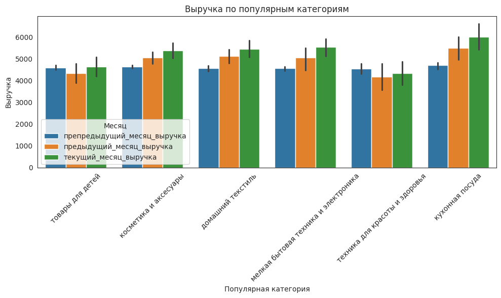

```python
# Преобразование данных для построения графика
X_test_melted_0 = X_test_full.query('предсказанная_покупательская_активность == 1').melt(id_vars='популярная_категория',
                                   value_vars=['препредыдущий_месяц_выручка', 'предыдущий_месяц_выручка', 'текущий_месяц_выручка'],
                                   var_name='месяц', value_name='выручка')

# Построение графика
plt.figure(figsize=(10, 6))
sns.barplot(data=X_test_melted_0, x='популярная_категория', y='выручка', hue='месяц')

plt.title('Выручка по популярным категориям')
plt.xlabel('Популярная категория')
plt.ylabel('Выручка')
plt.legend(title='Месяц')
plt.xticks(rotation=45)
plt.tight_layout()
plt.show()
```

У пользователей, активность которы предположительно не изменится, наоборот, заметен ощутимый рост выручки во всех сегментах, кроме "Товары для детей" и "Товары для красоты и здоровья".

По категории "Товары для себя и здоровья" заметна просадка по выручке в последние месяцы. Рекомендуется провести маркетинговые мероприятия, для увеличения продаж по данной категории товаров.

#### Выводы

1. **Сегмент 1: Максимальная доля покупок по акциям и высокая вероятность снижения активности**
- Эта группа активно участвует в акциях, что приводит к росту выручки, но их долгосрочная лояльность вызывает сомнения. Они могут лишь временно реагировать на скидки.
- **Рекомендации**:
  - **Программа лояльности**: Внедрить бонусную систему, где клиенты могут зарабатывать баллы за покупки, которые затем можно использовать для получения скидок или эксклюзивных предложений.
  - **Персонализированные предложения**: Использовать данные о поведении клиентов для создания индивидуальных акций на основе их предыдущих покупок, особенно в популярных категориях, таких как "Кухонная посуда" и "Товары для детей".
2. **Сегмент 2: Высокая вероятность снижения активности, товары с длинным жизненным циклом**
- Группа составляет лишь 2% пользователей и имеет низкую прибыльность. Фокусироваться на данном сегменте не имеет смысла.
3. **Сегмент 3: Высокая вероятность снижения активности и покупают товары из категории «Товары для себя» или «Товары для детей».**
- Обе группы требуют внимания, так как они демонстрируют снижение активности, но имеют разные предпочтения в категориях товаров. Обе группы одинаково важны, выделить одну из них в качестве приоритетной не получится.
4. **Сегмент 4: Высокая вероятность снижения активности, высокая прибыльность**
- Эти клиенты приносят много прибыли и составляют около 10% от общего количества покупателей. Это позволяет сосредоточиться на их удержании.
- **Рекомендации**:
  - **Персонализированные предложения**: Предлагать специальные акции и индивидуальные предложения для Группы 1, особенно на популярные категории "Косметика и аксесуары" и "Товары для детей".
  - **Поддержка постоянного контакта**: Регулярные обновления по электронной почте и уведомления о новых поступлениях в этих категориях помогут поддерживать интерес и вовлеченность клиентов.

**Общие рекомендации:**

- **Повышение лояльности:** Рекомендуется проводить мероприятия, направленные на повышение долгосрочной лояльности клиентов. Например, внедрить программу лояльности направленную на группу пользователей с максимальной долей покупок по акциям и высокая вероятность снижения активности, предусматривающую систему бонусов за постоянные покупки, что будет стимулировать повторные транзакции.
- **Удержание интереса:** Рекомендуется оптимизировать процесс покупки и взаимодействия с интернет-магазином, чтобы сделать его более удобным и приятным, а также увеличить время проводимое на сайте для всех категорий пользователей.
- **Персонализированная реклама:** Рекомендуется формировать персонализированную рекламу на основе смежных категорий товаров, чтобы увеличить среднее число просмотренных категорий пользователей. Например, для "товаров с коротким жизненным циклом" и "товаров для себя".
- **Скидки:** Для клиентов с высокой прибыльностью и высокой вероятностью снижения активности предложить дополнительные скидки.

## Заключение и общие рекомендации

**Описание задачи**

Цель исследования заключалась в разработке решения для персонализации предложений постоянным клиентам интернет-магазина «В один клик», чтобы увеличить их покупательскую активность. Снижение активности клиентов потребовало поиска способов удержания постоянных покупателей через персонализированные предложения.

**Исходные данные и предобработка**

Данные для анализа были представлены в четырех CSV-файлах, содержащих информацию о поведении покупателей, выручке, времени, проведённом на сайте, и среднемесячной прибыли. Проведённая предобработка включала:

- Кодирование целевой переменной и категориальных признаков.
- Масштабирование числовых данных.
- Удаление аномальных значений, которые могли исказить результаты анализа.

**Поиск лучшей модели**

```python
y_valid_pred = best_model.predict(X_valid)
y_valid_proba = best_model.predict_proba(X_valid)[:, 1]
y_test_pred = best_model.predict(X_test)
y_test_proba = best_model.predict_proba(X_test)[:, 1]
print(f'Метрика ROC-AUC на кросс-валидации (тренировочная выборка): {cross_val_score(best_model, X_train, y_train, cv=5, scoring="roc_auc").mean()}')
print(f'Метрика ROC-AUC на валидационной выборке: {roc_auc_score(y_valid, y_valid_proba)}')
print(f'Метрика ROC-AUC на тренировочной выборке: {roc_auc_score(y_test, y_test_proba)}')
```

```
Метрика ROC-AUC на кросс-валидации (тренировочная выборка): 0.9150132506261286
Метрика ROC-AUC на валидационной выборке: 0.9131313131313131
Метрика ROC-AUC на тренировочной выборке: 0.9193173975782671
```

**Лучшая модель**

Лучшая модель для предсказания снижения активности клиентов — SVC с вышеуказанными параметрами, которая продемонстрировала высокую точность и стабильность.

**Выводы и предложения для сегментации покупателей**

1. **Максимальная доля покупок по акциям и высокая вероятность снижения активности**:
   - Рекомендации: внедрить программу лояльности и персонализированные предложения.
2. **Высокая вероятность снижения активности, товары с длинным жизненным циклом**:
   - Не имеет смысла фокусироваться на этом сегменте.
3. **Высокая вероятность снижения активности и покупают товары из категории «Товары для себя» или «Товары для детей»**:
   - Рекомендации: активное использование персонализированных предложений в популярных категориях товаров.
4. **Высокая вероятность снижения активности, высокая прибыльность**:
   - Рекомендации: регулярные обновления, специальные скидки и индивидуальные предложения.

**Общие рекомендации**

- **Повышение лояльности:** Рекомендуется проводить мероприятия, направленные на повышение долгосрочной лояльности клиентов. Например, внедрить программу лояльности направленную на группу пользователей с максимальной долей покупок по акциям и высокая вероятность снижения активности, предусматривающую систему бонусов за постоянные покупки, что будет стимулировать повторные транзакции.
- **Удержание интереса:** Рекомендуется оптимизировать процесс покупки и взаимодействия с интернет-магазином, чтобы сделать его более удобным и приятным, а также увеличить время проводимое на сайте для всех категорий пользователей.
- **Персонализированная реклама:** Рекомендуется формировать персонализированную рекламу на основе смежных категорий товаров, чтобы увеличить среднее число просмотренных категорий пользователей. Например, для "товаров с коротким жизненным циклом" и "товаров для себя".
- **Скидки:** Для клиентов с высокой прибыльностью и высокой вероятностью снижения активности предложить дополнительные скидки.